# Problem Set 2 – Solution Set

Hunter C. Smith

Summer 2026

## Question 1.

1. Load the Fearon and Laitin data set (`fldata.RData`). What name shows up for the dataset in your environment? **(0.5 points)**

```r
rm(list = ls())
load("fldata.RData")
```

**ANSWER: The dataset is named “fl3”.**

2. What are the names of the variables stored in this dataset? How many variables do you have? What is your sample size, given this data set? (PLEASE DO NOT PRINT THE WHOLE DATASET IN YOUR OUTPUT!) **(0.5 points)**

```r
names(fl3)
```

```
##  [1] "cname"    "year"     "pop1"     "lpopl1"   "warl"     "war"
##  [7] "gdpenl"   "lmtnest"  "ncontig"  "Oil"      "nwstate"  "instab"
## [13] "polity2l" "ethfrac"  "relfrac"  "war_prop" "numyears"
```

```r
dim(fl3)
```

```
## [1] 156  17
```

**ANSWER: Names in output above. 156 observations, 17 variables.**

3. The variable `pop1` is population, measured in thousands of people. Show the sample distribution of this variable. Specifically, create a density plot, and a boxplot. Remember, plots need to be labelled. **(0.5 points)**

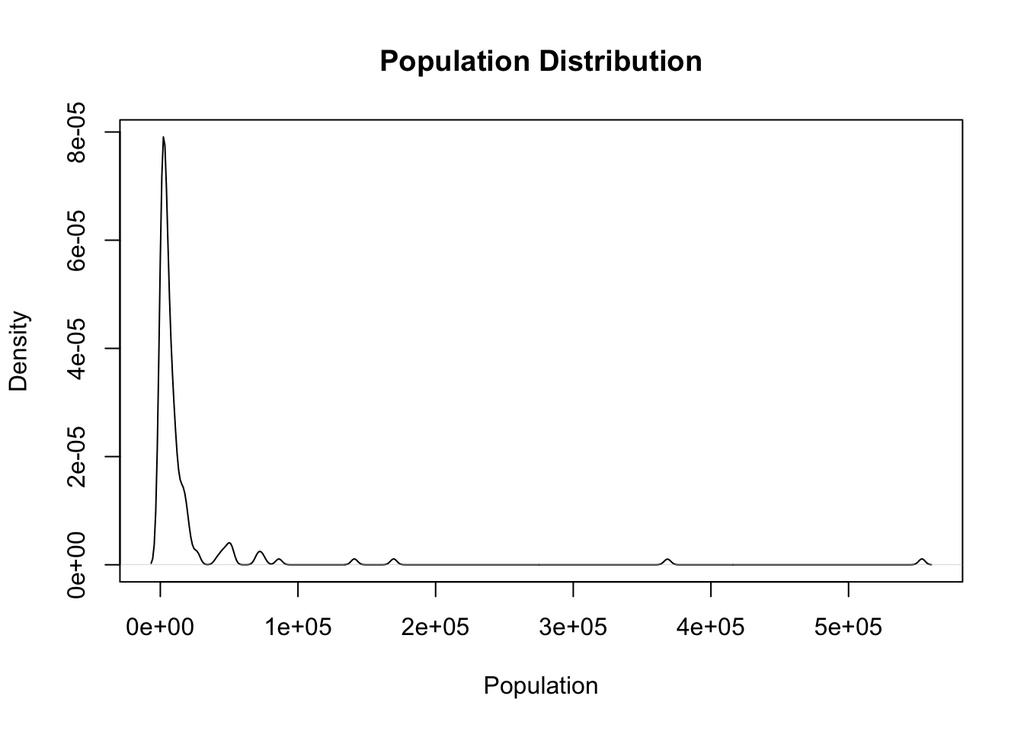

```r
plot(density(fl3$pop1),
     xlab = "Population",
     main = "Population Distribution")
```

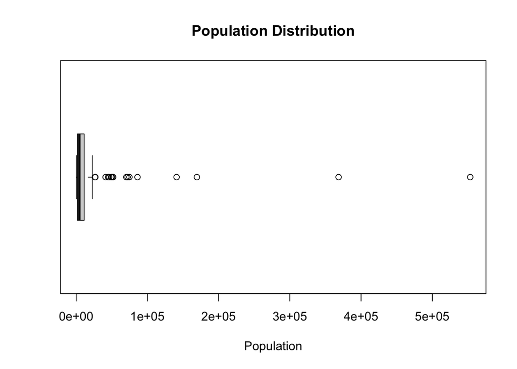

```r
boxplot(fl3$pop1,
        xlab = "Population",
        main = "Population Distribution",
        horizontal = T)
```

4. Remark on the shape of the distribution (density plot) in part (c). Compute the median and mean of `pop1` and report their values in your code. Then add these values to your chart as lines, including a legend to denote each line. Comment on whether the mean and median are the same and explain why or why not. If you were writing a paper using these data, would you report the mean or median as a measure of central tendency (choose only one)? Why did you make this choice based on your analysis? **(0.5 points)**

```r
mean(fl3$pop1)
```

```
## [1] 17586.24
```

```r
median(fl3$pop1)
```

```
## [1] 4517.001
```

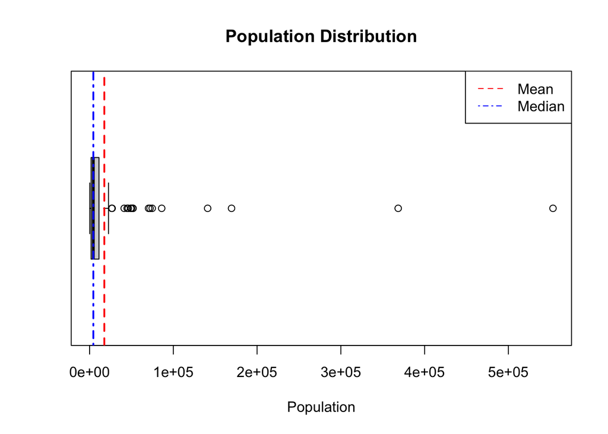

```r
boxplot(fl3$pop1,
        xlab = "Population",
        main = "Population Distribution",
        horizontal = T)
abline(v = mean(fl3$pop1), lty = 2, lwd = 2, col = "red")
abline(v = median(fl3$pop1), lty = 4, lwd = 2, col = "blue")
legend("topright",
       legend = c("Mean", "Median"),
       lty = c(2, 4),
       col = c("red", "blue"))
```

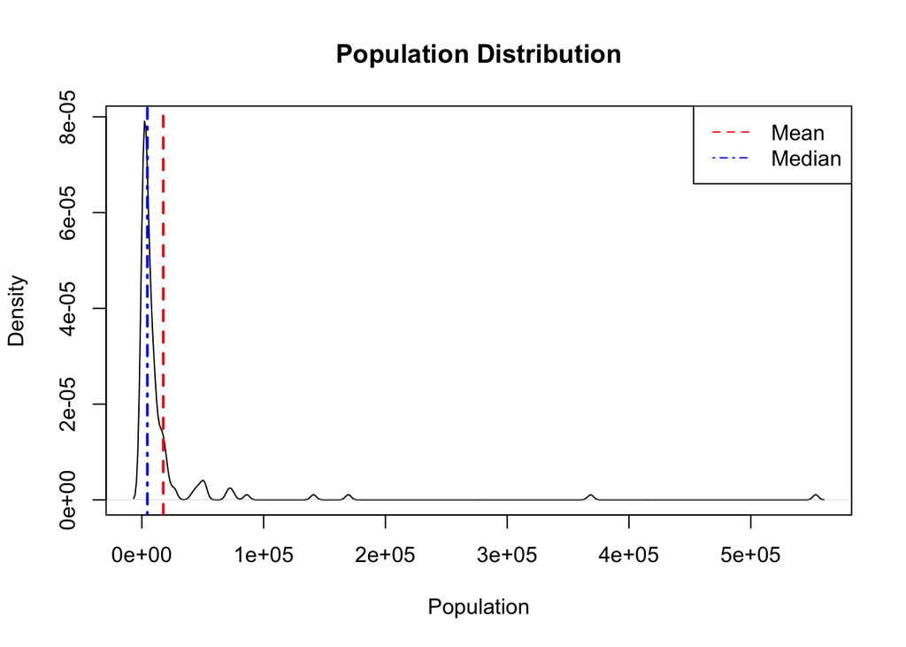

```r
plot(density(fl3$pop1),
     xlab = "Population",
     main = "Population Distribution")
abline(v = mean(fl3$pop1), lty = 2, lwd = 2, col = "red")
abline(v = median(fl3$pop1), lty = 4, lwd = 2, col = "blue")
legend("topright",
       legend = c("Mean", "Median"),
       lty = c(2, 4),
       col = c("red", "blue"))
```

**ANSWER: Mean is 17586.24, median is 4517.001. The distribution is positively skewed, which explains why the values are different. Mean is sensitive to outliers, median isn’t, so we should use the median in this case because it is less biased.**

In the same dataset, the variable `instab` describes whether each country in the dataset has experienced political regime instability or not. That is, whether it is a politically-unstable state (`instab` = 1), or politically-stable state (`instab` = 0). The variable `war` describes how many years from 1945 to 1999 that country had a civil war. The variable `ethfrac` is a measure of how fractionalized ethnic groups are in a given country – specifically, it’s the probability that two people randomly drawn from a given country are from the same (0) or different (1) ethnic groups.

5. What is the mean value of `war` for politically-unstable states? What is the mean value of `war` for politically-stable states? What is the standard deviation for both groups? What does this difference in standard deviations suggest about how much variation there is in war for politically-unstable versus stable states? Given these statistics, how confident are you in your ability to predict war experience for stable countries? for unstable countries? Explain your reasoning for each. **(1 point)**

```r
mean(fl3$war[fl3$instab == 1])
```

```
## [1] 12.4
```

```r
sd(fl3$war[fl3$instab == 1])
```

```
## [1] 6.348228
```

```r
mean(fl3$war[fl3$instab == 0])
```

```
## [1] 5.410596
```

```r
sd(fl3$war[fl3$instab == 0])
```

```
## [1] 10.54025
```

**ANSWER: For unstable states, the mean years in civil war is 12.4 and the SD is 6.35. For stable states, the mean years in civil war is 5.41 and the SD is 10.54. This means that there is more variation in `war` among politically stable states because the SD is larger. You would be more confident in predicting war experience for politically unstable states because its SD is smaller, meaning that there is overall less variation in the data so predictions would be more precise. The inverse is true for politically stable countries.**

6. Summarize the `ethfrac` variable: what is the minimum and maximum? What is the mean value? What is the median value? What is the standard deviation? Which measure of central tendency would you choose to report in a hypothetical research paper? Explain your choice. **(1 point)**

```r
summary(fl3$ethfrac)
```

```
##    Min. 1st Qu.  Median    Mean 3rd Qu.    Max.
##  0.0010  0.1438  0.3850  0.4083  0.6691  0.9250
```

```r
sd(fl3$ethfrac)
```

```
## [1] 0.2798512
```

**ANSWER: Min is 0.001, max is 0.925, mean is 0.408, median is 0.385, SD is 0.279. Mean and median are close together, so either answer could be acceptable with appropriate logic.**

7. Say you believe that increased ethnic fractionalization causes war. In this case, what is your independent and dependent variable? Make a scatterplot that shows the relationship between these two variables, including a regression line. Describe the relationship you find. What happens to the predicted number of years in civil wars as you move from no fractionalization to the highest possible value of fractionalization? Is there anything about the scatterplot itself that makes you question whether the regression line accurately portrays the relationship between ethnic fractionalization and war? Explain. **(1 point)**

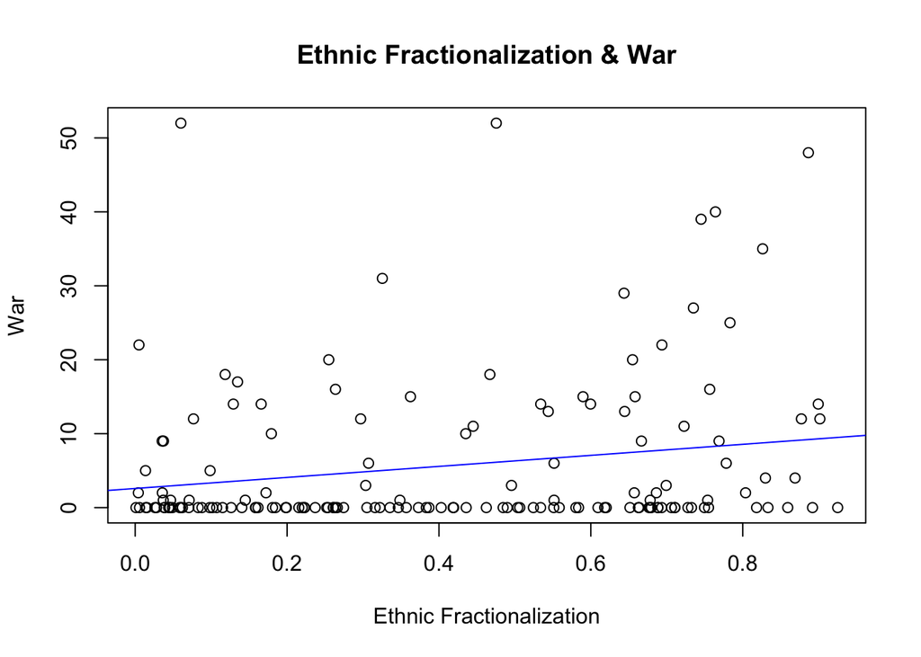

```r
plot(fl3$ethfrac, fl3$war,
     xlab = "Ethnic Fractionalization",
     ylab = "War",
     main = "Ethnic Fractionalization & War")
mod1 <- lm(war ~ ethfrac, data = fl3)
abline(mod1, col = "blue")
```

**ANSWER: IV is ethnic fractionalization, DV is war. The regression line is upward-sloping, indicating a positive relationship. On average, an increase in ethnic fractionalization is associated with a higher chance of war, but this is NOT a causal relationship. The scatterplot shows lots of zero values for the DV, which could provide a problem with accurate OLS estimation. Maybe a non-linear increase in war as ethfrac increases, particularly for high values.**

8. Pull up your model summary and interpret your estimates for $\beta_0$ and $\beta_1$. **(1 point)**

```r
summary(mod1)
```

```
##
## Call:
## lm(formula = war ~ ethfrac, data = fl3)
##
## Residuals:
##    Min     1Q Median     3Q    Max
## -9.492 -5.748 -3.583  2.404 48.964
##
## Coefficients:
##             Estimate Std. Error t value Pr(>|t|)
## (Intercept)    2.587      1.464   1.767   0.0792 .
## ethfrac        7.465      2.961   2.522   0.0127 *
## ---
## Signif. codes:  0 '***' 0.001 '**' 0.01 '*' 0.05 '.' 0.1 ' ' 1
##
## Residual standard error: 10.32 on 154 degrees of freedom
## Multiple R-squared:  0.03965,    Adjusted R-squared:  0.03341
## F-statistic: 6.358 on 1 and 154 DF,  p-value: 0.0127
```

**ANSWER: $\hat{\beta_0}$ tells us that when ethnic fractionalization is 0, the number of years a state spends in civil war is prdicted to be 2.587 years. $\hat{\beta_1}$ tells us that an increase in ethnic fractionalization of 1 (i.e., moving from its minimum to maximum value) is associated with a 7.465 year increase in civil war experience.**

## Question 2. Theory

Suppose you have a random variable $X$ with expectation $\mathbb{E}[X]=u$, and variance given by $Var[X] = s^2$. You then draw multiple observations from the same distribution. That is, you draw $X_1, X_2,..,X_n$, each a random variable wih expectation $\mathbb{E}[X] = u$ and variance $Var[X] = s^2$.

**(Hint: You should use the link from Section 4 to help you correctly format your mathematical notation. You must use correct notation to receive full credit for the following questions.)**

1. When you average these random variables together, what is it called? How do you write it mathematically? **(0.5 points)**

**ANSWER: The sample mean. $\overline{X} = \frac{1}{n} \Sigma (X_i)$**

2. What is the standard deviation of these random variables? How do you write it mathematically? **(0.5 points)**

**ANSWER: The standard deviation is $s$, or the square root of the variance. $\sigma_x = \sqrt{\sigma^2_x} = s$**

3. What is $\mathbb{E}[\overline{X}]$? Explain with math and words. **(0.5 points)**

**ANSWER: The expectation of the sample mean. $\mathbb{E}[\overline{X}] = \mathbb{E}[\frac{x_1 + ... + x_n}{n}] = \frac{1}{n} \mathbb{E}[X_i] = \frac{1}{n} \Sigma(u_i) = u$**

**Note: Students need not provide the full derivation of $\mathbb{E}[\overline{X}]$ but should at least include part of the derivation AND say that $\mathbb{E}[\overline{X}] = u$ for full credit.**

4. What is $Var[\overline{X}]$? Explain with math and words. **(0.5 points)**

**ANSWER: The variance of the sample mean. $Var(\overline{X}) = Var(\frac{\Sigma (X_i)}{n}) = (\frac{1}{n})^2 Var(X_i) = (\frac{1}{n})^2 n(s^2) = \frac{s^2}{n}$**

**Note: Students need not provide the full derivation of $Var[\overline{X}]$ but should at least include part of the derivation AND say that $Var[\overline{X}] = \frac{s^2}{n}$ for full credit.**

## Question 3.

1. In your own words, explain the difference between these terms and put them in a logical sequence: Estimate, Estimand, Estimator. Explain the logic behind your ordering of the terms. Give one original example of each – in other words, your example cannot be from the textbook, lecture slides, AI, or something the instructor or TAs said. **(1 point)**

**ANSWER: Estimator $\to$ Estimate $\to$ Estimand OR Estimand $\to$ Estimator $\to$ Estimate, depending on their explanation. Any reasonable example that differs from those discussed in course materials.**

2. If you repeatedly draw a sample and take a mean, how will the distribution of the mean change if the variance of the underlying population is small versus big? How will the distribution of the mean change if your sample size is small versus big? Explain your logic for each. **(1 point)**

**ANSWER: As variance of the population increases, so does the variance of the sample mean. As sample size increases, the variance of the sample mean decreases.**

## Question 4.

Did you collaborate with anyone on this problem set? If so, list them here.

**ANSWER: -0.5 points if unanswered.**

## Question 5.

Did you use generative AI on any part of this problem set? If so, identify which model you used and how you used it – specifically, identify all questions you used it for and explain how you used it for each question.

**ANSWER: -0.5 points if unanswered.**